# MUM 2024-25 Wybór optymalnego modelu konwolucyjnego

## różne własności

- modele konwolucyjne wprowadziły wiele nowych rozwiązań
  - AlexNet dał bardzo głębokie modele o powtarzających sie strukturach
  - VGG utworzył bloki
  - w VGG także powstały popularne konwolucje 3x3 pozwalające na przetwarzanie w strumieniu o tej samej szerokości (przy dodaniu minimalnego paddingu)
  - konwolucje 1x1 w Network-in-network dla zwiększenia czy dopasowania wymiarowości
  - GoogleLeNet dał przetwarzanie w wielu rozgałęzieniach dla "automatycznego" dopasowania wymiaru konwolucji do problemu na danym poziomie
  - ResNet, jako potomek Highway, pozwolił na wykorzystanie uczenia przez poprawę residuum, a stąd budowę bardzo głębokich sieci
    - Highway wciąż wykorzystywał aktywację sigmoidalną mimo, że ReLU powstało właśnie w tamtym ośrodku (Schmidhuber et al., patrz vanishing gradient, LSTM)!
  - ResNeXt dodał pogrupowane konwolucje, optymalizując obliczenia przy tej samej liczbie parametrów (trade-off)
  - SqueezeAndExcitation łączy informacje o kanałach z całego obszaru jako dodatkową wiedzę dla klasyfikacji
- wszystkie wymagają dobrego zaprojektowania modelu dla problemu
  - **manualne** zaprojektowanie: AlexNet, VGG, Iception, ResNet, ResNeXt, DenseNet, MobileNet
  - **zautomatyzowane**: poszukiwanie optymalnego rozwiązania w dobrze zaprojektowanej przestrzeni rozwiązań
  - **skalowanie** przez modyfikację kilku parametrów (głębokość, szerokość, rozdzielczość) znalezionego skutecznego modelu dla danego problemu do rozwiązania
  - **porównywanie** rozwiązań
- jak znaleźć model **automatycznie**?
  - metody *siłowe* przez szukanie optymalnych parametrów są bardzo kosztowne niczego nie gwarantując

## Projektowanie przestrzeni rozwiązań [[Radosavovic, Kosaraju, Girshick, He, Dollar, 2020]](https://openaccess.thecvf.com/content_CVPR_2020/papers/Radosavovic_Designing_Network_Design_Spaces_CVPR_2020_paper.pdf)

- zwykle szukamy **jednej** sieci dla **jednego** zadania

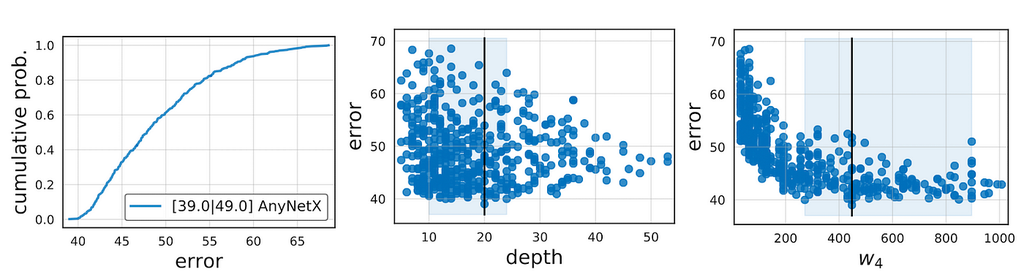

  - duża populacja modeli by obserwować ich zachowanie
  - można samplować modele z tej przestrzeni dla porównania jakości przestrzeni projektowania (design space)
    - samplujemy przestrzeń i patrzymy na rozkład błędu
    - zacząć na prostych zadaniach dla małej liczby epok znajdując rozkład od błędu (pierwszy po lewej)
    - oraz zależności względem różnych parametrów
    - można wykorzystać **bootstrap** dla lepszej dokładności w interesujących przedziałach
- konieczny jest **wzorzec** sieci: niech składa się z
  - **korzenia** (*stem*) dla wstępnego przetwarzania wejścia (większe konwolucje, etc.)
  - **ciała** (*body*) dla właściwego przetwarzania
    - ciało składa się z **etapów**, a każdy z nich z **bloków** odpowiadających blokom modeli konwolucyjnych
    - zwykle każdy z tych etapów zmniejsza wymiar (także korzeń)
  - **głowy** (*head*) która zamienia wyniki na interpretowalne wyjście, np. przez softamx
- niech problemem będzie ImageNet (224x224x3 -> r=224, c=3)

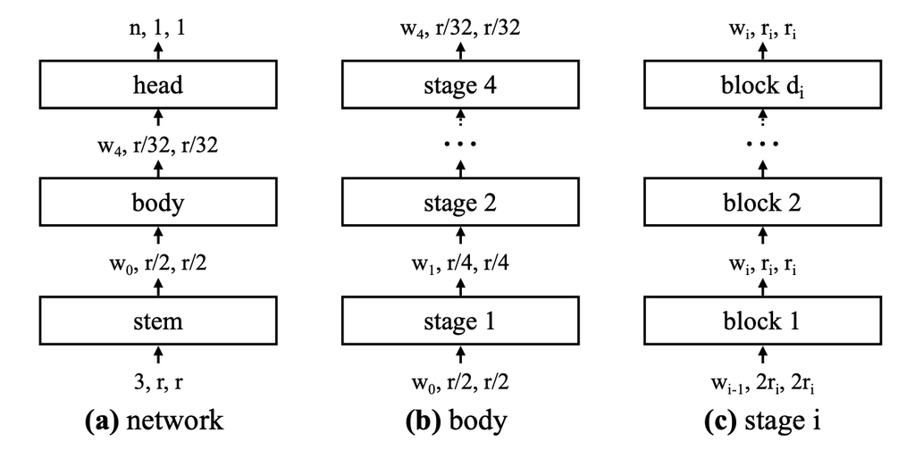

- stem zmniejsza wymiar do r/2 x r/2
- body składa się z 4 etapów z których każdy zmniejsza wymiar dwukrotnie
  - każdy etap składa się z bloków
    - tutaj typu ResNeXt
  - to daje w końcu $r/32 = 7$
- head wykorzystuje average pooling, dający efekt podobny do NiN,
  - na końcu dodatkowa warstwa fully-connected FC zwracająca n-elementowy wektor klasyfikacji
- wciąż można ustawić wiele parametrów
  - szerokość, liczbę bloków w etapie, przewężenia w blokach (bottleneck, patrz ResNeXt)
  - to daje kilkanaście hiperparametrów dla przeszukiwania przestrzeni rozwiązań
  - liczba możliwych modeli jest rzędu $10^{18}$ (dla pewnego układu parametrów bloków ResNeXt)
- dla znalezienia *sensownych* modeli samplujemy log-uniform dla
  - łącznej liczby bloków $d_i\leq16$
  - szerokości bloków $w_i\leq1024$, podzielnych przez 8
  - stosunku bottleneck $b_i\in\{1,2,4\}$
  - liczby grup $g_i\in\{1,2,\dots,32\}$
- samplujemy $n$ modeli, np. 500 ucząc każdy niedużą liczbę epok, np. 10
- w ten sposób estymujemy rozkład $p$, dla którego modele osiągają najniższy błąd
  - rozkład gęstości $$F(e,p)=P_{net\sim{}p}\{e(net)<e\}$$ błędu $e$ dla modeli z rozkładu $p$
  - stąd empiryczny rozkład $$\hat{F}(e,Z)=\dfrac{1}{n}\sum_{i=1}^n\mathbb{1}(e_i<e)$$ wszystkich modeli $net_i$ z błędem $e_i$ z próbki $Z=\{net_1,\dots,net_n\}$

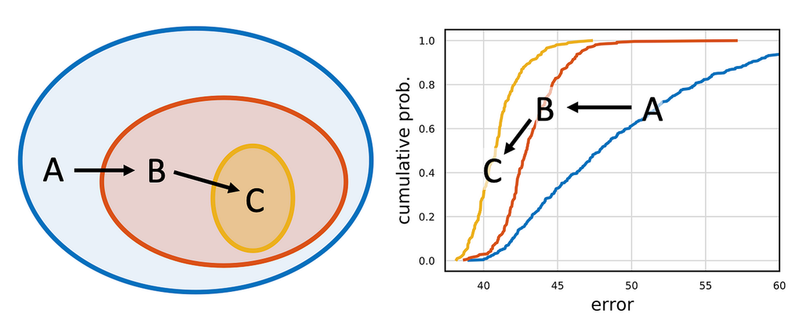

- hipoteza: jeśli wartość dla jednej próbki jest lepsza (majoryzuje) od innej, to parametry dla niej są lepsze
  - jeśli ustalić jeden z parametrów wspólny dla wszystkich sieci, to próbkowanie prawie natychmiast wybiera tylko kilka sensownych wartości tego parametru
  - lepsze wartości pozwalają na wejście do zawężonej przestrzeni parametrów, gdzie skuteczność modeli jest lepsza
- takie postępowanie pozwala stosunkowo szybko wybrać kilkadziesiąt, dających podobny minimalny błąd, modeli

### RegNet

- to daje kilkadziesiąt modeli definiujących nową przestrzeń rozwiązań, na przykład (przykładowe rozwiązanie z pracy dla ImageNet)
  - ten sam współczynnik bottleneck $b_i=b$
  - ta sama liczba grup w blokach ResNeXt $g_i=g$
  - zwiększenie szerokości w blokach ResNeXt $w_i\leq{}w_{i+1}$
  - zwiększenie głębokości w blokach ResNeXt $d_i\leq{}d_{i+1}$
- co zmniejsza wymiar przestrzeni rozwiązań z początkowych $\sim1.8\cdot10^{18}$ do ok. $3.0\cdot10^8$, wciąż przy dużej wariancji
- co ciekawe, można łatwo liniowo (!) dopasować wyniki najlepszych modeli dla $w_i$
  - można teraz (w uproszczeniu) wykonać skwantyfikowane poszukiwanie
    - dla danego modelu ustalić głębokość $d$
    - grid-search wyszukując optymalną szerokość $w_j$
- to pozwala zdefiniować **nową przestrzeń modeli** zdefiniowaną przez parametry głębokości d, parametry modelu dla szerokości, oraz znalezione wcześniej bottleneck b, i liczbę grup g
- to pozwala samplować tą przestrzeń i szukać optymalnego rozwiązania
  - pamiętając o liniowych aproksymacjach
  - teraz można także dłużej uczyć
- najlepsze 5 modeli uczymy już prawie w pełni